# Spatial Distribution Map - San Francisco Blackwood Acacias

Samantha Kuglen

January 22nd, 2022

## Overview

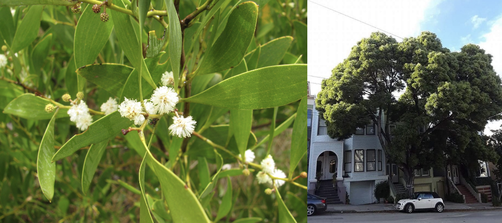

This report focuses on the analysis of tree data from San Francisco.

The main objective is to understand the **distribution and legal status of trees** across the city, focusing on Blackwood Acacia trees. The analysis incorporates a series of tasks, from data wrangling and visualization using `ggplot2` to spatial data handling and mapping via the `sf` and `tmap` packages.

```r
knitr::opts_chunk$set(echo = TRUE, message = FALSE, warning = FALSE)

library(tidyverse)
library(here)
library(sf)
library(tmap)

### Read in the data
sf_trees <- read_csv(here("data", "sf_trees", "sf_trees.csv"), show_col_types = FALSE)
```

## Background

Urban forestry plays a vital role in improving the environment and enhancing the quality of urban living. Recognizing the legal status and distribution of trees provides insights into

- Urban planning
- Conservation efforts, and
- Green landscape understanding of a city.

This analysis aims to shed light on these aspects using a dataset of trees from San Francisco.

## Part 1. Wrangling and plotting

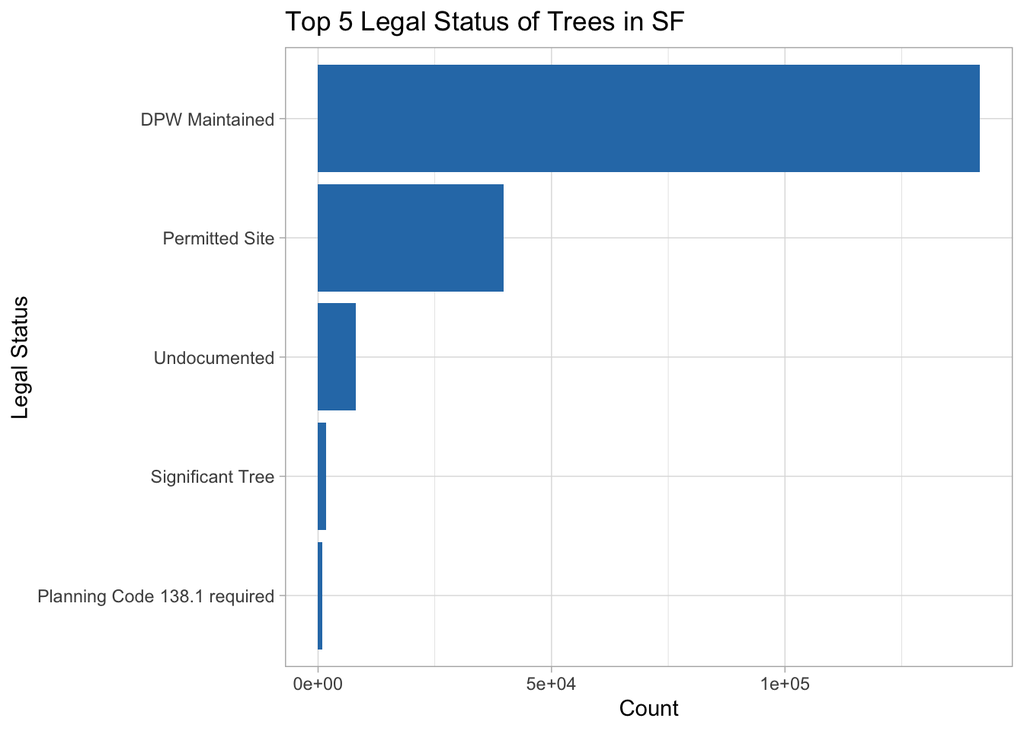

```r
top_5_status <- sf_trees %>%
  count(legal_status) %>%
  drop_na(legal_status) %>%
  arrange(-n) %>%
  head(5) %>%
  rename(tree_count = n)

ggplot(data = top_5_status, aes(x = fct_reorder(legal_status, tree_count), y = tree_count)) +
  geom_col(fill = "#2c7bb6") +
  labs(title = "Top 5 Legal Status of Trees in SF",
       x = "Legal Status",
       y = "Count") +
  coord_flip() +
  theme_light()
```

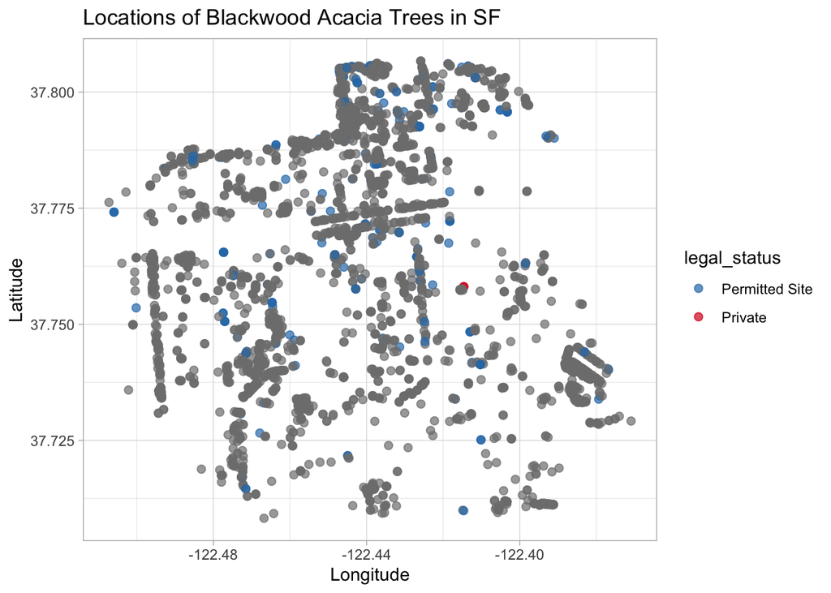

```r
permitted_data_df <- sf_trees %>%
  filter(legal_status %in% c("Permitted Site", "Private") & caretaker == "MTA")

blackwood_acacia_df <- sf_trees %>%
  filter(str_detect(species, 'Blackwood Acacia')) %>%
  select(legal_status, date, lat = latitude, lon = longitude)

ggplot(data = blackwood_acacia_df, aes(x = lon, y = lat)) +
  geom_point(aes(color = legal_status), size = 2, alpha = 0.7) +
  scale_color_manual(values = c("Permitted Site" = "#2c7bb6", "Private" = "#d7191c")) +
  labs(title = "Locations of Blackwood Acacia Trees in SF",
       x = "Longitude",
       y = "Latitude") +
  theme_light()
```

Separate species column into scientific and common names and use `tidyr::unite()`.

```r
sf_trees_sep <- sf_trees %>%
  separate(species, into = c("spp_scientific", "spp_common"), sep = ' :: ')
ex_5 <- sf_trees %>%
  unite('id_status', tree_id, legal_status, sep = '_COOL_')
```

## Part 2: Maps with Simple Features

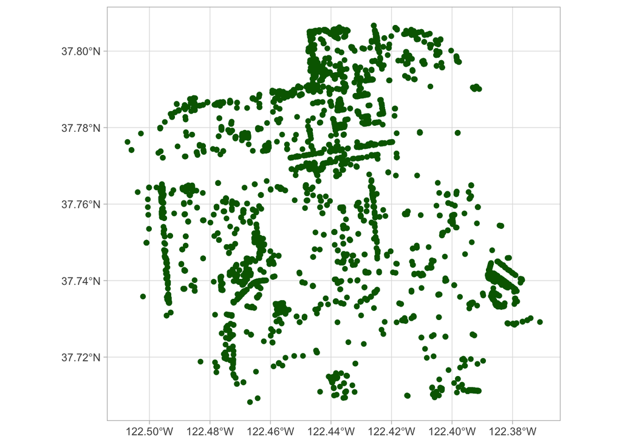

```r
blackwood_acacia_sf <- blackwood_acacia_df %>%
  drop_na(lat, lon) %>%
  st_as_sf(coords = c('lon', 'lat'), crs = 4326)

ggplot() +
  geom_sf(data = blackwood_acacia_sf, color = "darkgreen") +
  theme_light()
```

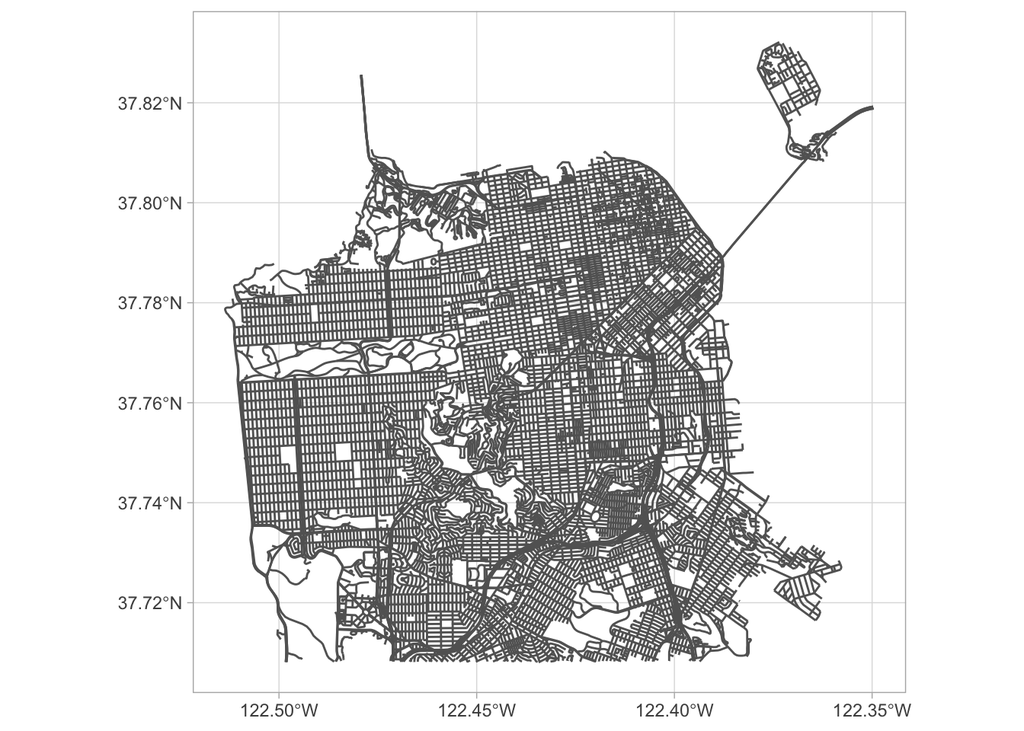

```r
sf_map <- read_sf(here('data', 'sf_map', 'tl_2017_06075_roads.shp'))

ggplot() +
  geom_sf(data = sf_map, size = 0.1, color = "#636363") +
  theme_light()
```

## Interactive map

```r
tmap_mode('view')
tm_shape(blackwood_acacia_sf) +
  tm_dots(col = "legal_status")
```

[interactive chart not shown]

### Implications & Importance

The interactive map provides a comprehensive visual representation of the distribution of Blackwood Acacia trees in San Francisco based on their legal status. Mapping this distribution is crucial as it assists urban planners in understanding where conservation efforts might be directed, especially if particular zones have a significant density of these trees.

Recognizing the legal status further highlights areas where the city or private entities might have jurisdiction. This aids in streamlining conservation efforts, especially in urban settings where rapid development and green spaces often clash. Further, the insights derived from such maps can inform future city planning, ensuring that urban growth considers and integrates natural green landscapes. This is vital not only for ecological balance but also for the well-being and quality of urban life, as green spaces are known to have numerous benefits, from improving air quality to enhancing the mental well-being of residents.